# Lab 4 - Árboles de Regresión

## 7.2 Definición de los límites

```r
p33 <- quantile(listings_clean$price_num, 0.33)
p67 <- quantile(listings_clean$price_num, 0.67)

cat("Percentil 33:", dollar(p33), "\n")
```

```
## Percentil 33: $137
```

```r
cat("Percentil 67:", dollar(p67), "\n")
```

```
## Percentil 67: $252
```

**Fundamento estadístico**: se utilizan los percentiles 33 y 67 de la distribución del precio como cortes, lo que genera tres grupos de tamaño aproximadamente igual (terciles). Este criterio es preferible a usar la media ± desviación estándar porque el precio tiene distribución asimétrica hacia la derecha (sesgo positivo): la media se ve inflada por propiedades muy caras y no representa bien el centro de la distribución. Con los terciles:

- **Económicas** (precio ≤ P33): el tercio inferior de propiedades por precio.
- **Intermedias** (P33 < precio ≤ P67): el tercio central.
- **Caras** (precio > P67): el tercio superior.

```r
datos_clasif <- listings_clean %>%
  mutate(
    categoria = case_when(
      price_num <= p33 ~ "Economica",
      price_num <= p67 ~ "Intermedia",
      TRUE             ~ "Cara"
    ),
    categoria = factor(categoria,
                       levels = c("Economica", "Intermedia", "Cara"),
                       ordered = FALSE)
  ) %>%
  select(categoria, accommodates, bedrooms, beds,
         review_scores_rating, reviews_per_month,
         minimum_nights, availability_365) %>%
  drop_na()

# Distribución de la variable respuesta
table(datos_clasif$categoria) %>%
  as.data.frame() %>%
  rename(Categoria = Var1, Frecuencia = Freq) %>%
  mutate(Porcentaje = round(Frecuencia / sum(Frecuencia) * 100, 1)) %>%
  kable(caption = "Distribución de la variable respuesta – Categoría de precio")
```

Distribución de la variable respuesta – Categoría de precio

| Categoria | Frecuencia | Porcentaje |
| --- | --- | --- |
| Economica | 20643 | 33.3 |
| Intermedia | 21029 | 33.9 |
| Cara | 20399 | 32.9 |

# 8 Actividad 7: Árbol de Clasificación

## 8.1 Partición de datos

```r
set.seed(123)

n_c           <- nrow(datos_clasif)
train_idx_c   <- sample(seq_len(n_c), size = 0.8 * n_c)

train_clasif  <- datos_clasif[train_idx_c, ]
test_clasif   <- datos_clasif[-train_idx_c, ]

cat("Filas entrenamiento:", nrow(train_clasif), "\n")
```

```
## Filas entrenamiento: 49656
```

```r
cat("Filas prueba:       ", nrow(test_clasif),  "\n")
```

```
## Filas prueba:        12415
```

## 8.2 Entrenamiento del árbol de clasificación

```r
set.seed(123)

arbol_clas <- rpart(
  categoria ~ .,
  data    = train_clasif,
  method  = "class",
  control = rpart.control(cp = 0.001, minsplit = 20, maxdepth = 6)
)

# Poda por cp óptimo
cp_clas <- arbol_clas$cptable[which.min(arbol_clas$cptable[, "xerror"]), "CP"]
arbol_clas_podado <- prune(arbol_clas, cp = cp_clas)

cat("cp óptimo (clasificación):", round(cp_clas, 6), "\n")
```

```
## cp óptimo (clasificación): 0.001
```

## 8.3 Visualización del árbol de clasificación

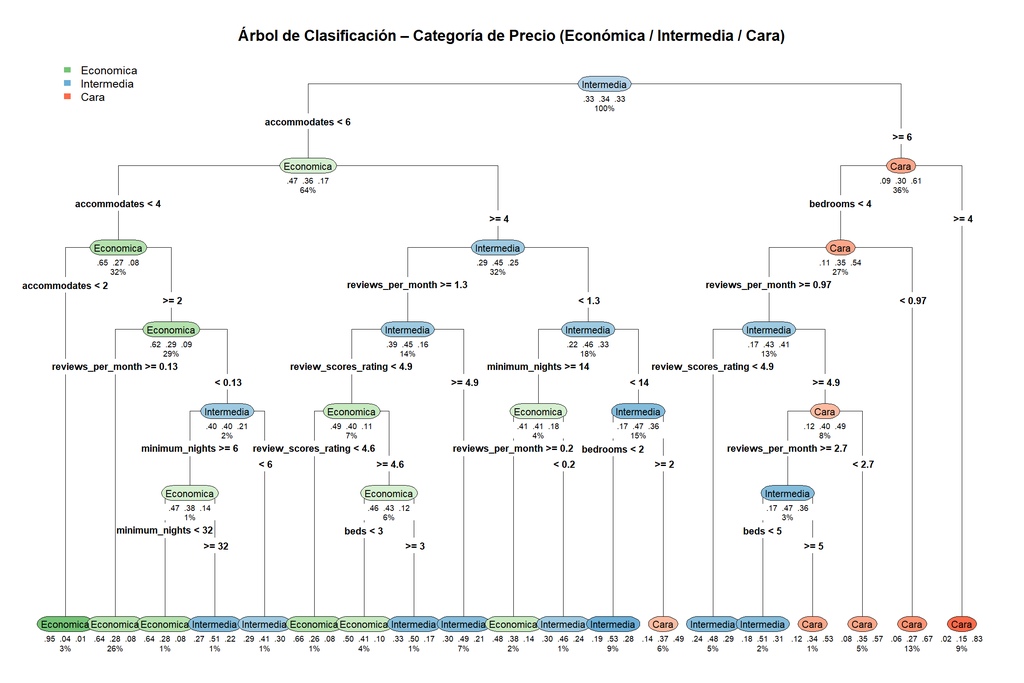

```r
rpart.plot(
  arbol_clas_podado,
  type    = 4,
  extra   = 104,    # muestra probabilidades de clase
  under   = TRUE,
  fallen.leaves = TRUE,
  main    = "Árbol de Clasificación – Categoría de Precio (Económica / Intermedia / Cara)",
  cex     = 0.7,
  box.palette = list("Greens", "Blues", "Reds")
)
```